# IWRL6432 Capon2D People Tracking Users Guide

## Overview

This example project demonstrates the use of TI IWRL6432 mmWave sensors to track moving and stationary people using the IWRL6432 sensor module in the wall-mount position.

This example features a 2D Capon processing chain which provides a dense and clustered point-cloud with good angular resolution for people tracking application.

In this demonstration, localization and tracking are performed upon any moving object in the scene. People or objects will continue being tracked until they leave the scene. People will even continue to be tracked as they sit or lie down and remain stationary.

With the 3D people tracking software running on the IWRL6432 chip, the mmWave sensor module outputs a number of data streams, including 3D point cloud information and a list of tracked objects which can be visualized using the PC based Industrial Visualizer included in the toolbox.

## Requirements

> 🛑 *Before Continuing!*  
> **xWRL6432 - ES2.0 Only**  
> For xWRL6432 devices, this demo is only compatible with ES2.0. To determine the ES version of your device, review the Determine Silicon Revision Guide

### Hardware Requirements

[output not shown]

### Additional Software Requirements

| Tool | Version | Download Link |
| --- | --- | --- |
| MMWAVE-L-SDK | 05.05.04.02 | https://www.ti.com/tool/MMWAVE-L-SDK |

## Quickstart

### 1. Configure the EVM for Flashing Mode

Place the IWRL6432AOP EVM in flashing mode as shown in the operational modes page

### 2. Flash the EVM using Uniflash

Flash the IWRL6432AOP EVM with the image found at `<RADAR_TOOLBOX_INSTALL_DIR>\source\ti\examples\Industrial_and_Personal_Electronics\People_Tracking\IWRL6432_Capon2D_People_Tracking\prebuilt_binaries\` using the latest version of Uniflash. Follow the instructions in Using Uniflash with mmWave

### 3. Configure the EVM for Functional Mode

Place the IWRL6432AOP EVM in functional mode as shown in the operational modes page

### 4. Open Visualizer

Navigate to `<RADAR_TOOLBOX_INSTALL_DIR>\tools\visualizers\Applications_Visualizer\Industrial_Visualizer`. The visualizer software may be run from Python 3.7.3 or as a standalone executable. In general, running the visualizer from the Python source runs faster and results in fewer errors over long periods of time. If running Python directly from source, run the setUpEnvironment.bat script first to ensure all the correct packages and versions are installed. Then run the visualizer either directly from source with `python gui_main.py`, or as an executable by running the `Industrial_Visualizer.exe`

### 5. Reset the IWRL6432AOP EVM by pressing the RESET_SW button

[figure not shown]

### 6. Select the arrowed options as shown in the below graphic.

1. Set the Device to IWRL6432 as indicated by arrow 1
2. Set CLI COM to the appropriate COM port as indicated by arrow 2. If the IWRL6432AOP EVM is plugged in when the visualizer is opened, then the COM ports filled in automatically. If they do not appear, check the Device Manager on Windows for the XDS110 Class Application/User UART port, and use this port number in the visualizer.

[figure not shown]

3. Select the IWRL6432 Out of Box Demo as indicated by arrow 3.
4. Press the “Connect” button as indicated by arrow 4
5. Press the “Select Configuration” button as indicated by arrow 5. Navigate to `<RADAR_TOOLBOX_INSTALL_DIR>\radar_toolbox\source\ti\examples\Industrial_and_Personal_Electronics\People_Tracking\IWRL6432_Capon2D_People_Tracking\chirp_configs` and select one of the configuration files present.
6. Press the “Start and Send Configuration” button as indicated by arrow 6. At this point you should see points and tracks appear as you move in front of the EVM.

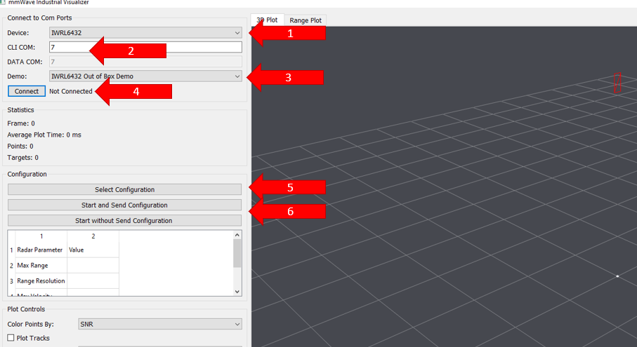

### 7. Optimal Physical Setup

1. For best results, the EVM should be positioned high enough to be above the top of tracked objects and with a slight down tilt. The aim is to position the EVM so that the antenna beam can encompass the area of interest. If the down tilt is too severe, noise from ground clutter would increase and the effective sensing area would decrease. If there is no down tilt, tracking performance would be worse for cases in which one person is in line with and shielded by another person.

> ⚠️ **Warning**  
> Whatever the height and tilt the radar is placed at, ensure that the sensorPosition line in the .cfg file reflects the position and angle of the radar.

> 📝 *NOTE: More Information*  
> For a more detailed discussion of the optimal placement and angle of the radar device, refer to TI’s Application Brief on the topic - [Best Practices for Placement and Angle of mmWave Radar Devices](https://www.ti.com/lit/swra758)

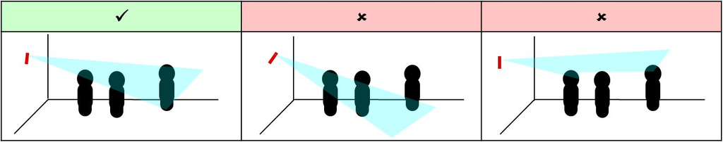

**Setup Requirements:**

- EVM Height: 1.5-2.5m high
- Down tilt angle: ~10 degrees

**Setup using suggested tripod and smartphone clamp mount:**

1. Screw on clamp mount to tripod
2. Clamp EVM across its width below power barrel jack to attach EVM
3. Adjust tripod head for ~10 degree down tilt (Tip: Bubble or level smartphone apps can be used to measure down tilt)
4. Plug in micro-usb and power supply to EVM
5. Extend tripod so that the EVM is elevated 1.5-2.5m from the ground
6. Position EVM and tripod assembly in desired location of room. The EVM should be positioned so that the 120 degree FOV of the EVM antenna encompasses the area of interest and points to the region in which people are expected to enter the space.

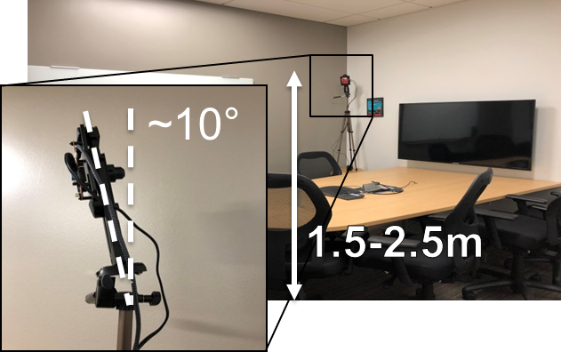

## Algorithm Overview

### Point Cloud Generation

This demo is an enhancement from the original xwrL64xx/14xx MCU+ SDK Motion and Presence Demo. Next, block diagram of different demos will be provided to highlight the difference.

#### Method 1 Original SDK Motion and Presence Demo

A block diagram is provided below

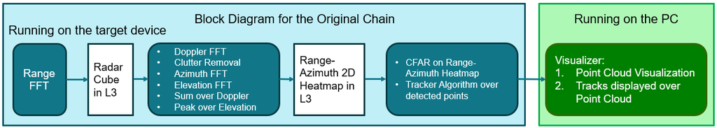

#### Method 2 Enhanced Chain with Capon

A block diagram is provided below

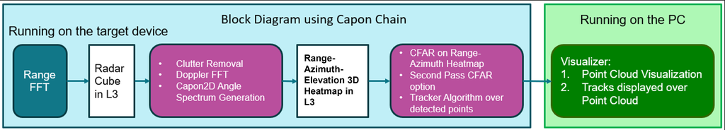

The major differences are listed below:

1. Range-azimuth-elevation “3D” heatmap is calculated (using Capon method) and stored.
2. CFAR is now running on range-azimuth heatmap for every elevation bins. Second pass CFAR option (on azimuth domain) is added. Dynamic CFAR threshold is added as an option.

In order to give good tracking performance when an object is moving as well as when it is stationary, this lab allocates tracks on point cloud generated by both Major Motion Mode and Minor Motion Mode.

In Major Motion mode, a single frame is used to generate range-azimuth-elevation heatmap. This gives good detection for faster movements like walking or waving. In Minor Motion mode, mutliple frames are used to generate range-azimuth-elevation heatmap. By using a sliding window of multiple frames, there is a finer granularity of detection with respect to time.

The detection layer chain of this demo runs two times using both the radar cube from the current frame [Major Motion] and the radar cube created across the current and previous frames [Minor Motion].

## Demo Specific Configuration File Parameters

### 1. The standard xwrL64xx MMWAVE-L-SDK CLI commands

Refer to the MMWAVE-L-SDK Motion and Presence Demo CLI INTERFACE Guide located at: `<SDK_INSTALL_DIR>/docs/api_guide_xwrL64xx/MOTION_AND_PRESENCE_DETECTION_DEMO.html`. Please download and install the MMWAVE-L-SDK 05.05.04.02 in order to access its users guide.

### 2. The commands that are specific to this demo binary

#### Angle Heatmap Generation Configuration

| angleHeatmapGenCfg 1 |
| --- |

[output not shown]

#### CFAR Configuration

| cfarCfg 2 8 4 3 0 9.0 0 1 4 6 2 9.0 0.8 0 0 0 1 1 1 1 0.5 1.5 0.15 |
| --- |

[output not shown]

## Demo Limitation

The following limitation applied to the demo chain.

- Although clutter removal can be enable or disabled. The demo performance is only tested with the clutter removal enabled.
- The phase compensation is always enabled.
- Range-azimuth-elevation heatmap is always in magnitude (not magnitude square).
- Capon Chain binary should be built in release mode only for the best MIPS optimization.

## Performance Tuning

The key items to focus on for tuning are as follows:

- **Proper mounting** - Ensure that all FOV and resolution constaints from the device are accounted for.
- **Point Cloud Tuning** - Users can adjust CFAR detection threshold in cfarCfg CLI to trade off between number of detected points vs false detection ratio.
  - Lower “thresholdScale[0-1]” results in richer point cloud but higher false detection ratio.  
    cfarCfg 2 8 4 3 0 `9.0` 0 1 4 6 2 `9.0` 0.8 0 0 0 1 1 1 1 0.5 1.5 0.15
  - Lower “sideLobeThreshold” results in a spreaded point cloud in azimuth direction.  
    cfarCfg 2 8 4 3 0 10.0 0 1 4 6 2 10.0 `0.8` 0 0 0 1 1 1 1 0.5 1.5 0.15
- **Point Cloud Spread Tuning** - A higher “sideLobeThreshold” can be set to control the point cloud spreading in azimuth direction and “enableLocalMaxElevation” can be set to 1 to control the point cloud spreading in elevation direction.  
  cfarCfg 2 8 4 3 0 10.0 0 1 4 6 2 10.0 `0.9` 0 0 `1` 1 1 1 1 0.5 1.5 0.15
- **Static leakage** - With overhead mounting, we sometimes observe false detection right under the sensor, which is caused by the strong floor reflection. This phenomenon is called **static leakage**. This type of false detection can be controlled through CFAR threshold adjustment based on angle and distance (dynamic threshold), which has been added to this demo code.

## FAQs

**Why do we get a denser point cloud using the Capon Beamforming Algorithm?**

The Capon beamformer results in a denser point cloud primarily for two reasons:

1. **Super-Resolution (Target Separation):** While FFT smears closely spaced reflections into a single peak, Capon’s sharper angular resolution separates them into distinct peaks. This resolves structure that FFT merges, generating more points for complex objects.
2. **Interference Rejection (Unmasking Weak Targets):** FFT suffers from spectral leakage (side lobes) where strong targets mask nearby weak targets. Capon adaptively suppresses this interference, lowering the effective noise floor around strong objects and allowing CFAR to detect weak reflection points that were previously hidden.

**What are the tradeoffs when using this demo over traditional FFT-based People Tracking?**

- **Higher computation:** The increased processing requirements result in higher frame periodicity, making this approach unsuitable for applications requiring faster frame rates.
- **No LPDS support:** Low Power mode is not supported in the current implementation.

## Need More Help?

- Search for your issue or post a new question on the [mmWave E2E forums for xWRLx432](https://e2e.ti.com/support/sensors-group/sensors/f/sensors-forum/1182245/faq-xwrlx432-common-questions-and-resources-for-xwrlx432)
- See the SDK for more documentation on various algorithms used in this demo. Start at `<MMWAVE_SDK_L_INSTALL_DIR>\docs\api_guide_xwrL64xx\index.html`